# Chapter5: Regression Analysis Using the Proportional Hazards Model

### Left Truncation

In Chapter 3 we discussed how left-truncation can arise in a clinical trial setting when the question of interest is time from diagnosis (rather than time from enrollment) to death or censoring. The same considerations arise in a comparative clinical trial.

To illustrate this, consider data from a hypothetical trial of six patients, three receiving an experimental treatment and three receiving a standard therapy.

```r
(df_left <- tibble(time   = c(6, 7, 10, 15, 19, 25),
                   status = c(1, 0, 1, 1, 0, 1),
                   group  = c(0, 0, 1, 0, 1, 1),
                   back_time = c(-3, -11, -3, -7, -10, -5)))
```

```
## # A tibble: 6 x 4
##    time status group back_time
##   <dbl>  <dbl> <dbl>     <dbl>
## 1     6      1     0        -3
## 2     7      0     0       -11
## 3    10      1     1        -3
## 4    15      1     0        -7
## 5    19      0     1       -10
## 6    25      1     1        -5
```

The time “time” represents the time from entry into the trial until death or censoring, “status” indicates whether or not a death was observed, and “group” indicates which group the patient is in. The time “back_time” refers to the backwards recurrence time, that is, the time before entry when the patient was diagnosed.

The data are plotted in Fig.

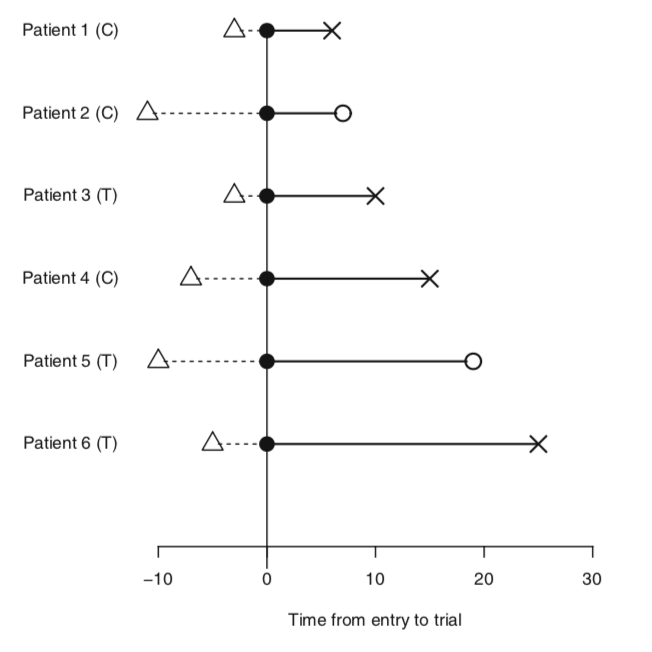

The standard way to compare the two groups is to ignore the backwards recurrence times:

```r
coxph(Surv(time, status) ~ group, data = df_left)
```

```
## Call:
## coxph(formula = Surv(time, status) ~ group, data = df_left)
##
##          coef exp(coef) se(coef)     z     p
## group -1.3261    0.2655   1.2509 -1.06 0.289
##
## Likelihood ratio test=1.21  on 1 df, p=0.2715
## n= 6, number of events= 4
```

This result shows that the experimental group has a lower hazard than the control group, but this difference is not statistically significant (p-value = 0.271 based on the likelihood ratio test).

There is nothing wrong with this standard and widely-used method; since there is no reason to believe that the backwards recurrence times would differ between the two groups, there should be no concern about bias. However, in some circumstances one may wish to compare survival times starting from time from diagnosis, and then it is essential to account for the left truncation.  
(診断から介入までの時間を考えなくても悪くはないが、診断からイベントまでの時間に興味があるときはleft trancationについて考えなければいけない)  
The data can be re-configured so that the diagnosis occurs at time 0 as follows:  
These data are plotted in Fig.

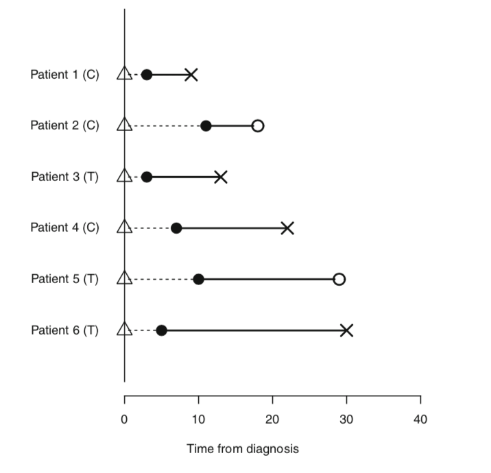

The left-truncated data may be compared as follows:

```r
coxph(Surv(-back_time, time - back_time, status, type="counting") ~ group, data = df_left)
```

```
## Call:
## coxph(formula = Surv(-back_time, time - back_time, status, type = "counting") ~
##     group, data = df_left)
##
##         coef exp(coef) se(coef)      z     p
## group -1.073     0.342    1.235 -0.869 0.385
##
## Likelihood ratio test=0.81  on 1 df, p=0.3677
## n= 6, number of events= 4
```

In this example, using the full survival times (from diagnosis) with left truncation leads to a similar non-significant treatment difference conclusion. (The option “type = ‘counting’” is not required, since the `Surv` function will use it by default in this case.)

Another example is the **Channing House data**, which we discussed in Chapter 3.  
We may compare the survival of men and women, accounting for the different ages of entry.

```r
head(ChanningHouse)
```

```
##    sex entry exit time cens
## 1 Male   782  909  127    1
## 2 Male  1020 1128  108    1
## 3 Male   856  969  113    1
## 4 Male   915  957   42    1
## 5 Male   863  983  120    1
## 6 Male   906 1012  106    1
```

As before, we condition on subjects reaching the age of 68. We have to do this explicitly, since the “start.time” option we used previously is not available in the `coxph` function,

```r
CH_68 <- ChanningHouse %>%
  tbl_df() %>%
  mutate(entry = entry / 12, exit = exit / 12, time = time / 12) %>%   # convert months to years
  filter(exit >= 68)  # filter exit >= 68

coxph(Surv(entry, exit, cens, type = "counting") ~ sex, data = CH_68)
```

```
## Call:
## coxph(formula = Surv(entry, exit, cens, type = "counting") ~
##     sex, data = CH_68)
##
##           coef exp(coef) se(coef)     z     p
## sexMale 0.2733    1.3143   0.1762 1.552 0.121
##
## Likelihood ratio test=2.3  on 1 df, p=0.1292
## n= 451, number of events= 172
```

Here are the results, which show that men have a higher hazard (and hence lower survival) than do women, but this difference is not statistically significant:

### Exercise

1. Consider the data set `aml`, which is included in the `survival` package.  
   This is a study of whether or not maintenance therapy increases survival among patients with acute myelogenous leukemia, with survival time measured in weeks.

```r
glimpse(aml)
```

```
## Observations: 23
## Variables: 3
## $ time   <dbl> 9, 13, 13, 18, 23, 28, 31, 34, 45, 48, 161, 5, 5, 8, 8, …
## $ status <dbl> 1, 1, 0, 1, 1, 0, 1, 1, 0, 1, 0, 1, 1, 1, 1, 1, 0, 1, 1,…
## $ x      <fct> Maintained, Maintained, Maintained, Maintained, Maintain…
```

The basic Cox model may be fitted as follows:

```r
coxph(Surv(time, status) ~ x, data = aml)
```

```
## Call:
## coxph(formula = Surv(time, status) ~ x, data = aml)
##
##                  coef exp(coef) se(coef)     z      p
## xNonmaintained 0.9155    2.4981   0.5119 1.788 0.0737
##
## Likelihood ratio test=3.38  on 1 df, p=0.06581
## n= 23, number of events= 18
```

Create a coarser time variable by expressing it in months instead of weeks as follows:

```r
aml2 <- aml %>%
  as_data_frame() %>%
  mutate(time_month = time %/% 4 + if_else(time %% 4 == 0, 0, 1))
```

Now re-fit the model, modeling ties using the Breslow, Efron, and exact methods.  
Which approximate method gives a result closest to that from the exact method?

```r
# make list of `coxph`
tie_methods <- c("exact", "breslow", "efron")
lst_result <- tie_methods %>%
  purrr::set_names() %>%
  map(~ coxph(Surv(time_month, status) ~ x, data = aml2, ties = .))

# make list of "coef"
lst_coef <- map(c(1, 2, 3), ~ lst_result[[.]]$coef) %>%
  purrr::set_names(tie_methods)

# View coefs
lst_coef
```

```
## $exact
## xNonmaintained
##       0.845995
##
## $breslow
## xNonmaintained
##      0.7405137
##
## $efron
## xNonmaintained
##      0.8041398
```

2. Consider again the synthetic data in Chapter 4, discussed in Example.

```r
(df3 <- tibble(patient = 1:6,
               survtime = c(6, 7, 10, 15, 19, 25),
               censor = c(1, 0, 1, 1, 0, 1),
               group = c("C", "C", "T", "C", "T", "T")))
```

```
## # A tibble: 6 x 4
##   patient survtime censor group
##     <int>    <dbl>  <dbl> <chr>
## 1       1        6      1 C
## 2       2        7      0 C
## 3       3       10      1 T
## 4       4       15      1 C
## 5       5       19      0 T
## 6       6       25      1 T
```

Use the `basehaz` function to obtain an estimate of the baseline cumulative hazard function.  
Use this to compute the predicted survival curves for the control and experimental groups based on the proportional hazards.

```r
# fit cox proportional hazards model
fit <- coxph(Surv(survtime, censor) ~ group, data = df3)
summary(fit)   # HR = 0.2655
```

```
## Call:
## coxph(formula = Surv(survtime, censor) ~ group, data = df3)
##
##   n= 6, number of events= 4
##
##           coef exp(coef) se(coef)     z Pr(>|z|)
## groupT -1.3261    0.2655   1.2509 -1.06    0.289
##
##        exp(coef) exp(-coef) lower .95 upper .95
## groupT    0.2655      3.766   0.02287     3.082
##
## Concordance= 0.7  (se = 0.116 )
## Likelihood ratio test= 1.21  on 1 df,   p=0.3
## Wald test            = 1.12  on 1 df,   p=0.3
## Score (logrank) test = 1.27  on 1 df,   p=0.3
```

```r
# estimate hazard by K-M method
(KM <- surv_fit(Surv(survtime, censor) ~ 1, data = df3) %>%
  surv_summary() %>%
  select(1:5) %>%
  mutate(hazard = n.event / n.risk, cum_hazard = cumsum(hazard)))
```

```
##   time n.risk n.event n.censor      surv    hazard cum_hazard
## 1    6      6       1        0 0.8333333 0.1666667  0.1666667
## 2    7      5       0        1 0.8333333 0.0000000  0.1666667
## 3   10      4       1        0 0.6250000 0.2500000  0.4166667
## 4   15      3       1        0 0.4166667 0.3333333  0.7500000
## 5   19      2       0        1 0.4166667 0.0000000  0.7500000
## 6   25      1       1        0 0.0000000 1.0000000  1.7500000
```

```r
# estimate baseline cumulative hazard function
baseline_hazard <- basehaz(fit, centered = FALSE) %>%
  mutate(surv_rate_control = exp(-hazard),
         surv_rate_treatment = surv_rate_control ^ (exp(fit$coeff)))

# compare baseline cumulative hazard vs K-M method
KM %>%
  inner_join(rename(baseline_hazard, baseline_hazard = hazard), by = "time")
```

```
##   time n.risk n.event n.censor      surv    hazard cum_hazard
## 1    6      6       1        0 0.8333333 0.1666667  0.1666667
## 2    7      5       0        1 0.8333333 0.0000000  0.1666667
## 3   10      4       1        0 0.6250000 0.2500000  0.4166667
## 4   15      3       1        0 0.4166667 0.3333333  0.7500000
## 5   19      2       0        1 0.4166667 0.0000000  0.7500000
## 6   25      1       1        0 0.0000000 1.0000000  1.7500000
##   baseline_hazard surv_rate_control surv_rate_treatment
## 1       0.2633999       0.768434561           0.9324559
## 2       0.2633999       0.768434561           0.9324559
## 3       0.8200350       0.440416253           0.8043492
## 4       1.4732003       0.229190841           0.6762861
## 5       1.4732003       0.229190841           0.6762861
## 6       5.2396357       0.005302188           0.2487917
```